# LDA

Jilung Hsieh

2022-04-17

```r
knitr::opts_chunk$set(echo = TRUE, cache = T)
```

# Introduction

1. Getting word tokens by `doc_term_count <- unnest()`
2. Building DocumentTermMatrix by `dtm <- tidytext::cast_dtm(doc_term_count, title, words, n)`
3. Getting word tokens by `word_token <- unnest()`
4. Building DocumentTermMatrix by `dtm <- tidytext::cast_dtm(word_token, title, words, n)`
5. Modeling by `dtm_lda <- topicmodels::LDA(dtm, k = 16, control = list(seed = 1234))`
6. Results
   1. Visualize word-topic probability by `dtm_topics <- tidy(dtm_lda, matrix = "beta")`
   2. Getting document-topic probability
   3. Building term network
7. Evaluation
   1. Calculating perplexity by different number of topics
   2. Evaluating by `library(ldatuning)`

## Resource

- https://www.tidytextmining.com/ngrams.html
- https://docs.google.com/presentation/d/13JZupGAV-tZt8qR9gf1uq339EQo8NpvOnVl7vORTo6g/edit?usp=sharing

# Set-ups

```r
library(tidyverse)
library(stringr)
library(tidytext)
library(jiebaR)
library(lubridate)
# devtools::install_github("bmschmidt/wordVectors")
library(wordVectors)
library(word2vec)
library(tidyr)
options(scipen = 999)
# " xcode-select --install"
# install.packages("http://download.r-forge.r-project.org/src/contrib/tmcn_0.2-9.tar.gz", repos = NULL, type = "source")
# library(tmcn)

# install.packages("devtools")
# devtools::install_github("qinwf/ropencc") # Convert S to Trad
```

```r
load("data/s3_watched.rda")

Sys.setlocale(locale="zh_TW.UTF-8")
```

```
## [1] "zh_TW.UTF-8/zh_TW.UTF-8/zh_TW.UTF-8/C/zh_TW.UTF-8/zh_TW.UTF-8"
```

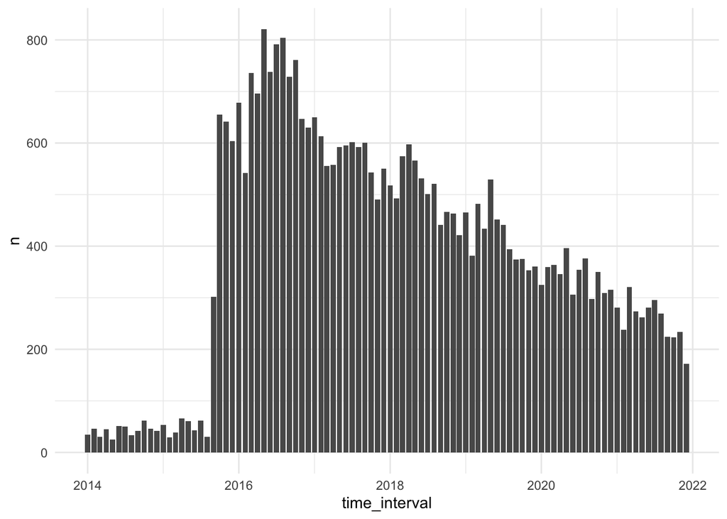

```r
s3.watched %>%
    select(doc_id, ptime) %>%
    filter(!duplicated(.)) %>%
    mutate(time_interval = floor_date(ptime, unit = "month")) %>%
    count(time_interval) %>%
    ggplot() + aes(time_interval, n) +
    geom_col() + theme_minimal()
```

```r
s3.watched %>%
    extract(ptitle, "label", "\\[(.+?)\\]", remove = F) %>%
    select(doc_id, label) %>%
    distinct(doc_id, label) %>%
    count(label, sort = T) %>% head(50)
```

```
## # A tibble: 50 × 2
##    label     n
##    <chr> <int>
##  1 寶寶  20759
##  2 懷孕   4463
##  3 生產   2065
##  4 心得   1959
##  5 <NA>   1660
##  6 月子   1383
##  7 母乳    954
##  8 好康    439
##  9 群組    344
## 10 新聞    338
## # … with 40 more rows
```

```r
library(jiebaR)
stopWords <- readRDS("data/stopWords.rds")
segment_not <- c("爸爸", "爸媽", "新手")
watched <- c("爸爸","父親","老公","先生","丈夫","奶爸",
             "寶爸","隊友","爹地","爸比","把拔","把鼻",
             "老爸","另一半","拔拔", "孩子的爸","孩子爸",
             "爸拔","他爸","她爸","新手爸","版爸", "板爸",
             "我家男人","當爸的","腦公","阿爸","人父",
             "孩子的爹","孩子爹","老爹","外子","拔比",
             "爸鼻","爸把","爸逼","爸咪","把爸","拔爸",
             "爹低","帥爸","準爸","小孩爸","親爸","神爸",
             "宅爸","瓶餵爸","寶寶的爸","孩的爸","女兒的爸")

reserved <- c("神隊友", "豬隊友", "好隊友", "好先生", "好爸爸", "好老公")

watched <- c(watched, reserved)

watched.str <- paste0(watched, collapse = "|")


reserved <- c("神隊友", "豬隊友", "好隊友", "好先生", "好爸爸", "好老公")

cutter <- worker()
tagger <- worker("tag")
new_user_word(cutter, segment_not)
```

```
## [1] TRUE
```

```r
new_user_word(cutter, watched)
```

```
## [1] TRUE
```

```r
new_user_word(tagger, segment_not)
```

```
## [1] TRUE
```

```r
new_user_word(tagger, watched)
```

```
## [1] TRUE
```

# Text-pre-processing

```r
unnested.df <- s3.watched %>%
    filter(str_detect(sentence, "隊友")) %>%
    mutate(word = purrr::map(s3, function(x)segment(x, cutter))) %>%
    unnest(word) %>%
    anti_join(stopWords) %>%
    filter(!str_detect(word, "[a-zA-Z0-9]+")) %>%
    filter(!is.na(word)) %>%
    group_by(word) %>%
    filter(n() > 5) %>%
    ungroup() %>%
    filter(nchar(word) > 1) %>%
    filter(!word %in% c("隊友"))
doc_term_count <- unnested.df %>%
    group_by(doc_id, word) %>%
    filter(n() > 1) %>%
    ungroup() %>%
    count(doc_id, word)
```

```r
library(tidytext)
dtm <- doc_term_count %>%
    cast_dtm(doc_id, word, n)
# dtm %>% View
```

# LDA

```r
library(topicmodels)
dtm_lda <- LDA(dtm, k = 8, control = list(seed = 1234))
dtm_lda4 <- LDA(dtm, k = 4, control = list(seed = 1234))
```

# Visual exploration

## Word-topic probabilities

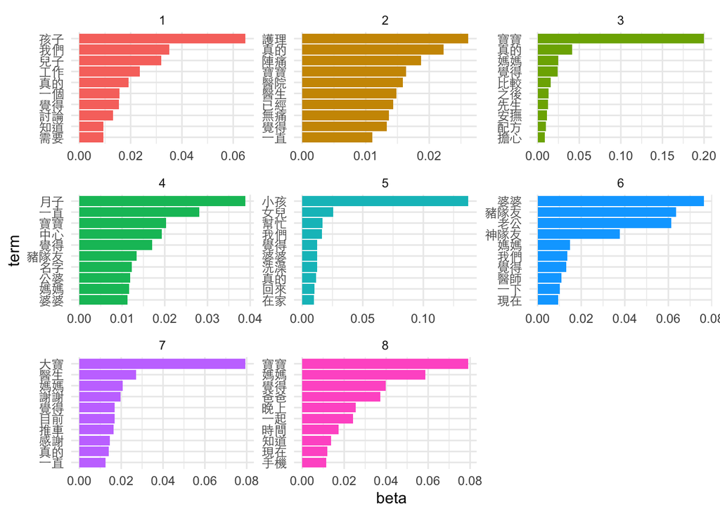

```r
dtm_topics <- tidy(dtm_lda, matrix = "beta")

top_terms <- dtm_topics %>%
    group_by(topic) %>%
    top_n(10, beta) %>%
    ungroup() %>%
    arrange(topic, -beta)

top_terms %>%
    mutate(term = reorder_within(term, beta, topic)) %>%
    ggplot(aes(beta, term, fill = factor(topic))) +
    geom_col(show.legend = FALSE) +
    facet_wrap(~ topic, scales = "free") +
    scale_y_reordered() +
    theme_minimal() +
    theme(axis.text.y=element_text(family="Heiti TC Light"))
```

Note. Using `recode()` to change facet names (topics)

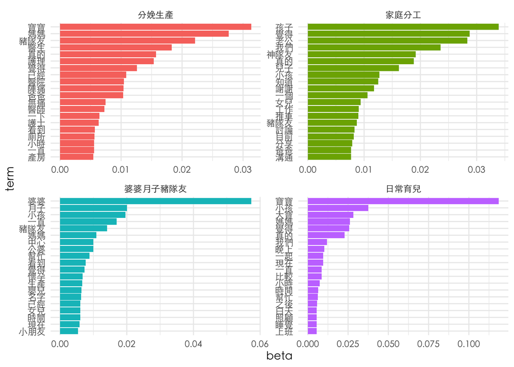

```r
dtm_topics_4 <- tidy(dtm_lda4)

top_terms_4 <- dtm_topics_4 %>%
    group_by(topic) %>%
    top_n(20, beta) %>%
    ungroup() %>%
    arrange(topic, -beta)
# View(top_terms_4)

top_terms_4 %>%
    mutate(term = reorder_within(term, beta, topic)) %>%
    mutate(topic = recode(topic,
                          "1"="家庭分工",
                          "2"="分娩生產",
                          "3"="日常育兒",
                          "4"="婆婆月子豬隊友")) %>%
    ggplot(aes(beta, term, fill = factor(topic))) +
    geom_col(show.legend = FALSE) +
    facet_wrap(~ topic, scales = "free") +
    scale_y_reordered() +
    theme_minimal() +
    theme(title = element_text(family="Heiti TC Light"),
          text = element_text(family="Heiti TC Light"),
          axis.text.y=element_text(family="Heiti TC Light"))
```

## Evaluation

```r
perplexity(dtm_lda)
```

```
## [1] 462.068
```

```r
perplexity(dtm_lda4)
```

```
## [1] 585.4096
```

```r
# [1] 348.7432
# [1] 592.8917


# Example of entroty
-(0.6*log2(0.6) + 0.4*log2(0.4))
```

```
## [1] 0.9709506
```

```r
-(0.9*log2(0.9) + 0.1*log2(0.1))
```

```
## [1] 0.4689956
```

```r
# [1] 0.9709506
# [1] 0.4689956
```

```r
library(tidyverse)
n_topics <- c(4, 8, 12, 16, 20, 24, 32, 48, 64)

# perplex <- sapply(n_topics, function(k){
#   lda.temp <- LDA(dtm, k =k, control = list(seed = 1109))
#   perplexity(lda.temp)
# })

topicsbyk <- list()
s_time <- Sys.time()
for(i in 1:length(n_topics)){
    message(i, "\t", n_topics[i], "\t", Sys.time() - s_time)
    topicsbyk[[i]] <- list()
    topicsbyk[[i]]$k <- n_topics[i]
    lda.temp <- LDA(dtm, k = n_topics[i], control = list(seed = 1109))
    topicsbyk[[i]]$model <- lda.temp
    topicsbyk[[i]]$perplex <- perplexity(lda.temp)
}
```

```
## 1    4   0.0132391452789307
```

```
## 2    8   1.89817404747009
```

```
## 3    12  6.53883600234985
```

```
## 4    16  14.6342129707336
```

```
## 5    20  26.3636529445648
```

```
## 6    24  41.8467710018158
```

```
## 7    32  1.04004026651382
```

```
## 8    48  1.43532673517863
```

```
## 9    64  2.29146338303884
```

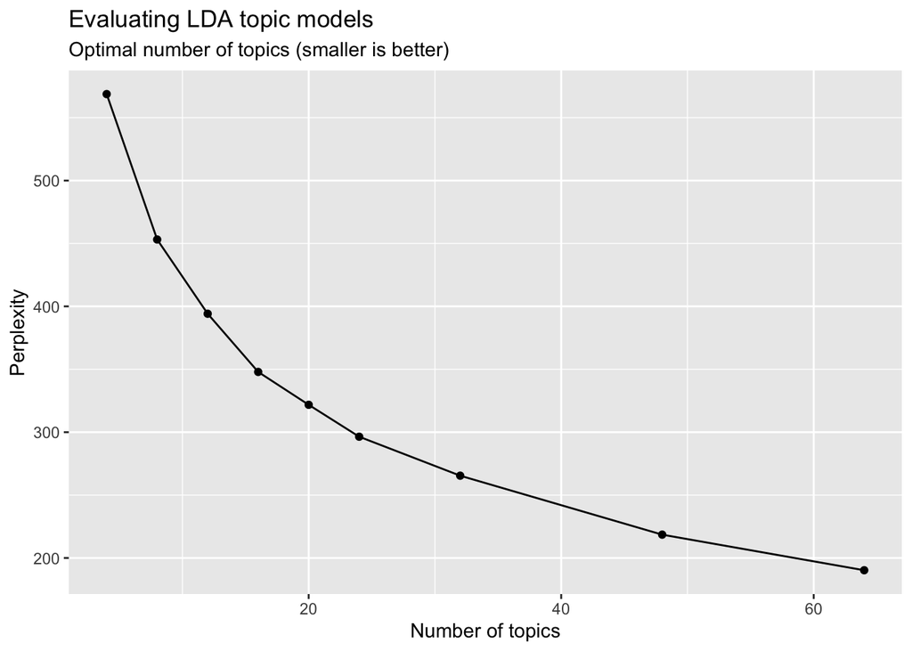

```r
perplex <- topicsbyk %>%
    purrr::map(function(x){x$perplex}) %>%
    unlist()

tibble(k=n_topics, perplex=perplex) %>%
    ggplot(aes(k, perplex)) +
    geom_point() +
    geom_line() +
    labs(title = "Evaluating LDA topic models",
         subtitle = "Optimal number of topics (smaller is better)",
         x = "Number of topics",
         y = "Perplexity")
```

## Comparing topic1 and topic 2

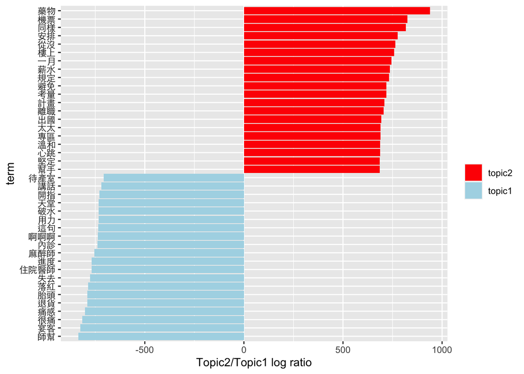

```r
library(tidyr)

beta_spread <- dtm_topics %>%
    mutate(topic = paste0("topic", topic)) %>%
    spread(topic, beta) %>%
    select(term, topic1, topic2) %>%
    filter(topic1 > .001 | topic2 > .001) %>%
    mutate(logratio = log2(topic1 / topic2)) %>%
    arrange(desc(logratio))

# beta_spread

beta_spread %>%
    group_by(logratio > 0) %>%
    top_n(20, abs(logratio)) %>%
    ungroup() %>%
    mutate(term = reorder(term, logratio)) %>%
    ggplot(aes(term, logratio, fill = logratio < 0)) +
    geom_col() +
    coord_flip() +
    ylab("Topic2/Topic1 log ratio") +
    scale_fill_manual(name = "", labels = c("topic2", "topic1"),
                      values = c("red", "lightblue")) +
    theme(axis.text.y=element_text(colour="black", family="Heiti TC Light"))
```

# Document-topic probabilities

```r
doc_topics <- tidy(dtm_lda, matrix = "gamma") %>%
    spread(topic, gamma)

dtm_lda@gamma %>% head()
```

```
##              [,1]         [,2]         [,3]        [,4]       [,5]        [,6]
## [1,] 0.0249783597 0.0249783288 0.0249783287 0.024978348 0.82515164 0.024978329
## [2,] 0.0018636813 0.0018636812 0.0018636810 0.001863681 0.98695423 0.001863681
## [3,] 0.8251516826 0.0249783449 0.0249783287 0.024978329 0.02497833 0.024978329
## [4,] 0.0249783287 0.0249783287 0.0249783287 0.024978329 0.02497833 0.825151698
## [5,] 0.0138755129 0.4583734614 0.0138755129 0.013875513 0.01387551 0.013875513
## [6,] 0.0009831946 0.0009831948 0.0009831946 0.208560920 0.58051208 0.206011028
##              [,7]         [,8]
## [1,] 0.0249783287 0.0249783352
## [2,] 0.0018636808 0.0018636812
## [3,] 0.0249783287 0.0249783287
## [4,] 0.0249783287 0.0249783293
## [5,] 0.0138755176 0.4583734567
## [6,] 0.0009831942 0.0009831952
```

```r
# doc_topics
```

## Visualizing document-topic

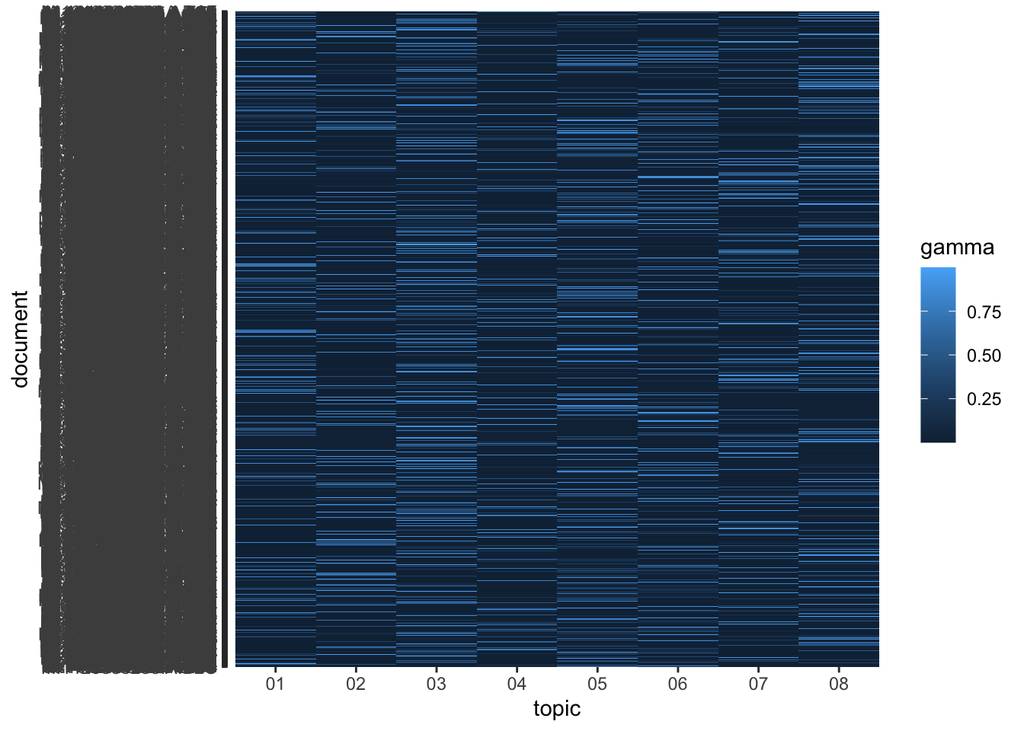

```r
tidy(dtm_lda, matrix = "gamma") %>%
    mutate(topic = str_pad(topic, 2, pad = "0")) %>%
    # mutate(gamma = log10(gamma)) %>%
    # spread(topic, gamma)
    ggplot() + aes(topic, document, fill = gamma) +
    geom_raster()
```

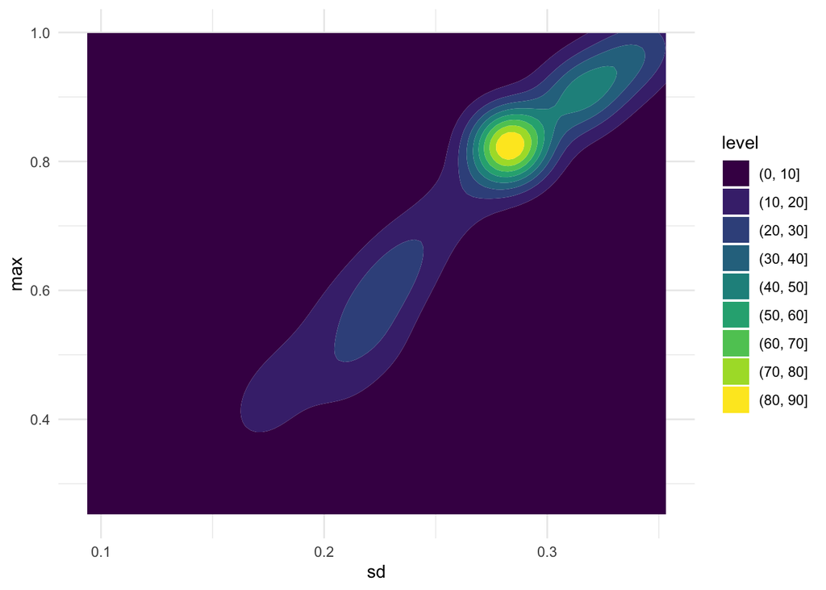

```r
tidy(dtm_lda, matrix = "gamma") %>%
    mutate(topic = str_pad(topic, 2, pad = "0")) %>%
    group_by(document) %>%
    summarize(sd = sd(gamma),
              max = max(gamma)) %>%
    ungroup() %>%
    ggplot() + aes(sd, max) +
    geom_density_2d_filled() +
    # geom_density2d() +
    theme_minimal()
```

# LDAVis

- https://ldavis.cpsievert.me/reviews/reviews.html
- https://github.com/m-clark/topic-models-demo/blob/master/topic-model-demo.Rmd
- https://gist.github.com/christophergandrud/00e7451c16439421b24a
- http://christophergandrud.blogspot.tw/2015/05/a-link-between-topicmodels-lda-and.html

# Acknowledgement

- This page is derived in part from “[Tidy Text Mining with R](https://www.tidytextmining.com/)” and licensed under a Creative Commons Attribution-NonCommercial-ShareAlike 3.0 United States License.
- This page is derived in part from “[What is a good explanation of Latent Dirichlet Allocation?](https://www.quora.com/What-is-a-good-explanation-of-Latent-Dirichlet-Allocation)”
- This page is dervied in part from the course “[Computing for Social Science](http://cfss.uchicago.edu/fall2016/syllabus.html)” in uChicago.
- https://chengjunwang.com/zh/post/cn/cn_archive/2013-09-27-topic-modeling-of-song-peom/
- http://www.bernhardlearns.com/2017/05/topic-models-lda-and-ctm-in-r-with.html

# Term network

```r
# install.packages("widyr")
library(widyr)
word_pairs <- unnested.df %>%
    pairwise_count(word, doc_id, sort = TRUE)
word_corr <- unnested.df %>%
    group_by(word) %>%
    filter(n() > 20) %>%
    pairwise_cor(word, doc_id, sort = TRUE)
```